# COVID-19 Kansas Weekly Forecast Summary

[The COVID-19 Forecast Hub Team](https://covid19forecasthub.org/doc/) https://covid19forecasthub.org/

2021-06-01

# Background

This report provides a brief summary of the weekly ensemble forecast for Kansas from the [COVID-19 Forecast Hub](https://covid19forecasthub.org/). In collaboration with the US CDC, our team aggregates COVID-19 forecasts from dozens of teams around the globe. Typically on Wednesday of each week, a summary of the week’s forecasts from the COVID-19 Forecast Hub appear on the [official CDC COVID-19 forecasting page](https://www.cdc.gov/coronavirus/2019-ncov/covid-data/forecasting-us.html).

Every week, teams submit their forecasts to the COVID-19 Forecast Hub.

Each Tuesday, we combine the most recent forecasts from each team into a single “ensemble” forecast of reported COVID-19 cases at the county, state, and national level and deaths at the state and national level. At the moment, we only generate ensemble forecasts for four weeks into the future, as [the available evidence](https://www.medrxiv.org/content/10.1101/2021.02.03.21250974v1) suggests that models are less accurate at longer forecast horizons.

Weekly reports from the COVID-19 Forecast Hub can be found at [this page](https://covid19forecasthub.org/doc/reports/).

# COVID-19 Forecasts

Since the inputs to the ensemble model do not factor in changes in behavior or policy that could have an impact on short-term disease transmission (e.g. school openings or closures, new interventions, governmental policy shift, etc…), the ensemble model itself should not be looked to for specific answers to questions like “what will happen if or when schools open in 2 weeks” because most of the input models are not factoring in these changes. That said, the ensemble model has consistently shown strong predictive performance in predicting mortality, and very few of the many interventions put in place appear to have created dramatic changes in short-term disease transmission that would impact short-term trends in mortality.

## State level

This week, our ensemble combined forecasts for Kansas from 44 different models.

During periods of relative stability, models in general show broad agreement about the predicted trajectory of the outbreak. However, when there are steep surges or declines in cases or deaths, models often have quite different predictions for the upcoming weeks. The result is that there is increased uncertainty in the ensemble forecast, which can be seen as wider confidence intervals in the forecast visualization. You can explore the full set of models, including their forecasts for past weeks online at our [interactive forecast visualization](https://viz.covid19forecasthub.org/).

When interpreting probability of an increase, it’s important to note that the increase or decrease is relative to the location-specific recent observed incidence, which varies across locations.

### Deaths

At the state level, the ensemble model predicts that weekly totals of observed deaths in each of the next four weeks will be between 12 and 17 deaths each week with around 5,140 total deaths by June 26. However for the week ending June 26, the ensemble shows substantial uncertainty, with observed deaths between 0 and 50 deemed possible (95% prediction interval: 1 - 47).

For state-level death forecasts made over the last 6 weeks in Kansas for which observed data are now available, the 95% prediction intervals covered the truth 100% of the time, and the 50% prediction intervals covered the truth 83% of the time.

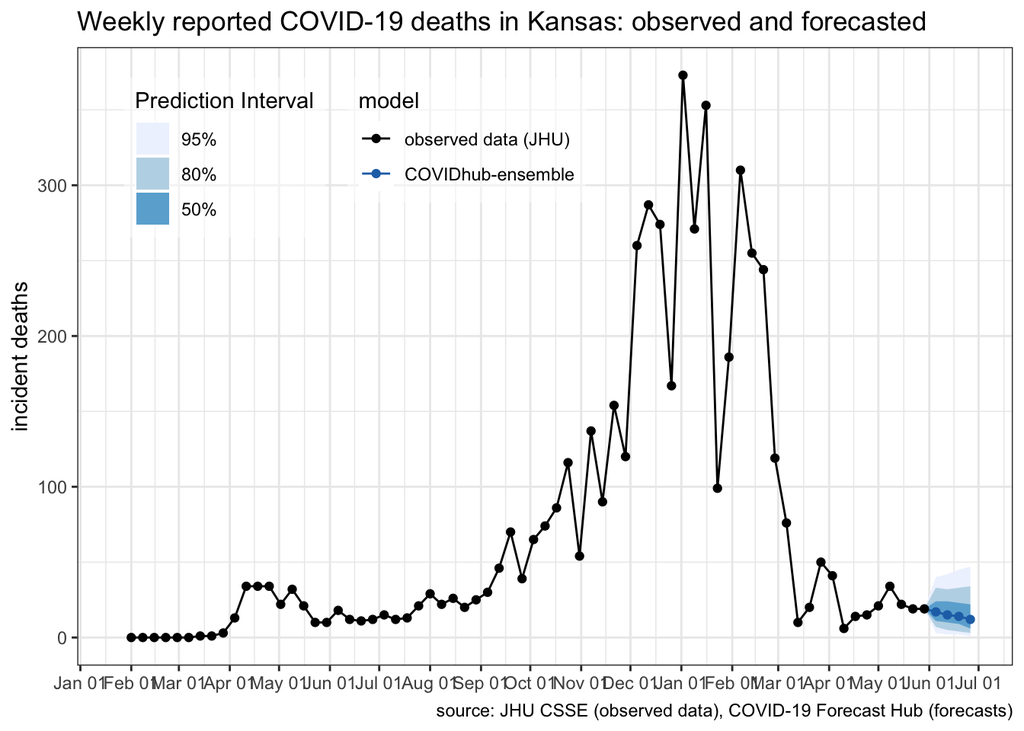

The sortable and searchable death table below shows the total number of reported COVID-19 deaths at the US level and state level for Kansas as of Saturday, May 29, 2021 (“Total COVID-19 Deaths”) as well as the rate of reported COVID-19 deaths in the population (standardized per 100,000 population) over the last two weeks and over the next two weeks.

| state | Population | Total COVID-19 deaths | Daily deaths per 100k, last 2 weeks | Daily deaths per 100k, next 2 weeks | Death rate difference |
| --- | --- | --- | --- | --- | --- |
| Kansas | 2913314 | 5077 | 0.093 | 0.081 | -0.012 |
| United States | 332875137 | 594306 | 0.181 | 0.135 | -0.046 |

### Hospitalizations

The ensemble model predicts that COVID-19 daily hospitalizations will be between 7 and 19 hospitalizations daily. However for June 28, 2021, the ensemble shows substantial uncertainty, with COVID-19 daily hospitalizations between 0 and 25 deemed possible.

For state-level hospitalization forecasts made over the last 6 weeks in Kansas for which observed data are now available, the 95% prediction intervals covered the truth 96% of the time, and the 50% prediction intervals covered the truth 62% of the time.

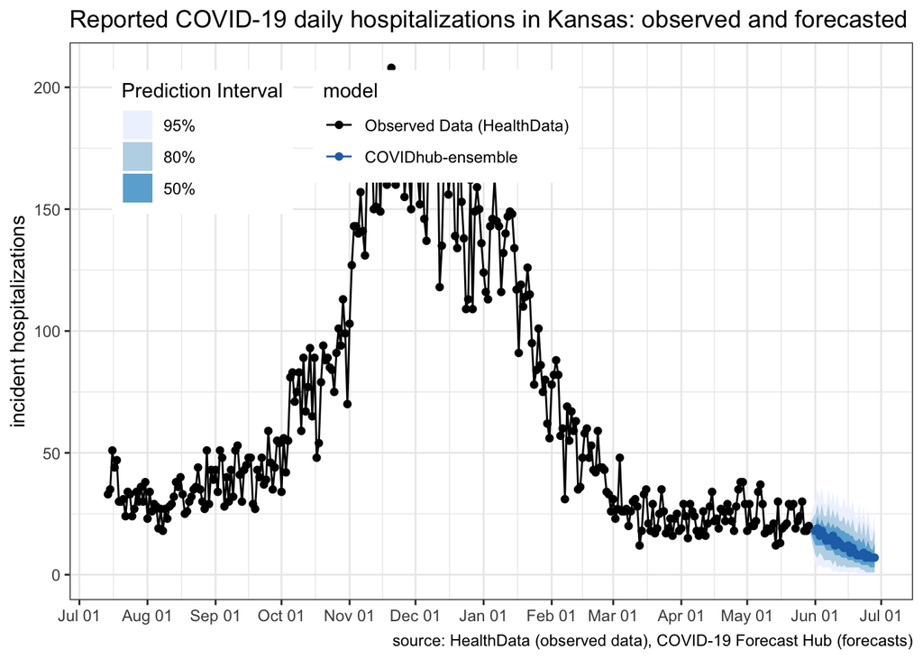

The sortable and searchable hospitalization table below shows the 7 day average hospitalization count and rate of reported COVID-19 hospitalization in the population (standardized per 100,000 population) over the last week (May 23, 2021 to May 29, 2021) and two weeks ahead (June 06, 2021 to June 12, 2021).

[interactive table not shown]

### Cases

The ensemble model predicts that weekly totals of observed cases in each of the next four weeks will be between 450 and 850 cases each week. However for the week ending June 26, the ensemble shows substantial uncertainty, with observed cases between 0 and 1,900 deemed possible (95% prediction interval: 0 - 1,916).

For state-level case forecasts made over the last 6 weeks in Kansas for which observed data are now available, the 95% prediction intervals covered the truth 100% of the time, and the 50% prediction intervals covered the truth 88% of the time.

Figure 2: Weekly observed and forecasted COVID-19 cases. Observed data from [JHU CSSE](https://github.com/CSSEGISandData/COVID-19/tree/master/csse_covid_19_data/) and forecasts from the [COVID-19 Forecast Hub](https://covid19forecasthub.org/).

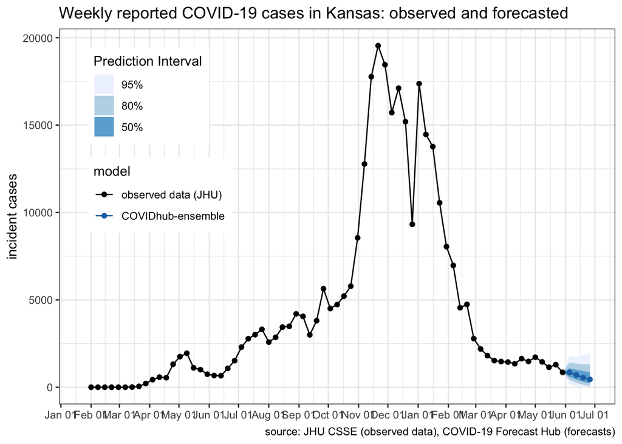

The sortable and searchable case table below shows the weekly case count and rate of reported COVID-19 case in the population (standardized per 100,000 population) over the last week (May 23, 2021 to May 29, 2021) and two weeks ahead (June 06, 2021 to June 12, 2021).

[interactive table not shown]

## County level

County-level forecasts are only made for cases. County-level case forecasts are presented below.

Cases reported in unknown counties or by people who reside outside of the state are not included in Table 3, but are included in the state-level data.

Select a County

[interactive chart not shown]

The sortable and searchable table below shows the total number of reported COVID-19 cases at the county level for Kansas as of Saturday,May 29, 2021 (“Total COVID-19 Cases”) as well as the rate of reported COVID-19 cases in the population (standardized per 100,000 population) over the last two weeks and over the next two weeks.

For county-level case forecasts made over the last 6 weeks in Kansas for which observed data are now available, the 95% prediction intervals covered the truth 100% of the time and the 50% prediction intervals covered the truth 88% of the time.

Looking at the rates allows for easier comparison across counties, where you can see which counties have had or are predicted to have propoportionally higher rates in comparison to other counties. These tables calculate the weekly case count and rate of reported COVID-19 cases in the population (standardized per 100,000 population) over the last week(May 23, 2021 to May 29, 2021) and two weeks ahead (June 06, 2021 to June 12, 2021).

When interpreting probability of an increase, it’s important to note that the increase or decrease is relative to the location-specific recent observed incidence, which varies across locations.

[interactive table not shown]

# Methods & Acknowledgement

This report was reproducibly and dynamically generated using RMarkdown. The code for the report can be found [here](https://github.com/reichlab/covid19-forecast-hub/tree/master/code/reports).